# 消費者の異質性と住宅立地

岩田真一郎（神奈川大学経済学部）

2026-01-25作成，2026-03-19改訂

［PDF形式：1000KB］

東京23区の住宅価格は近年，上昇を続けています．このような状況では，どのような属性を持った消費者に都心の住宅地が割り当てられるのでしょうか？これを考える手がかりとして，所得や世帯構成の違いがあげられます．実際，年収が高く共働きのいわゆる[パワーカップル](https://ja.wikipedia.org/wiki/%E5%85%B1%E5%83%8D%E3%81%8D)は高価格の都心近郊に住み，一方で子育て世帯は，安価で広い住宅を求めて郊外に住む傾向にあるといわれます（倉橋，2021；堀，2023；日本経済新聞，2025）．[^1]

このことを示すのが．図1と図2です．図1（a）および（b）は1都3県（島嶼部を除く）において，都心ほど1人あたり課税所得が高く，郊外に向かうにつれてそれが低くなる傾向を示しています．[^2]

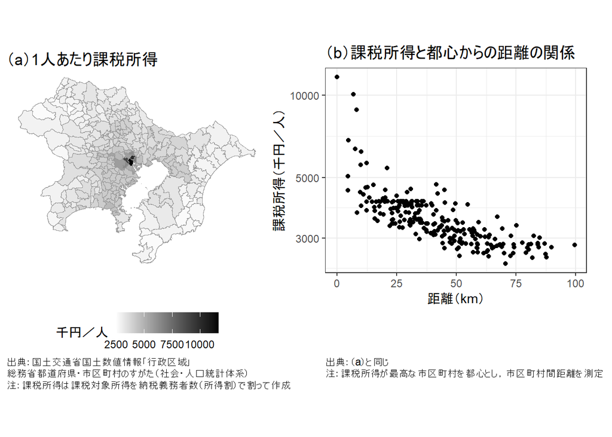

図1：1都3県市区町村別の1人あたり課税所得（2020年度）

図2（a）および（b）は同じ1都3県で，都心ほど世帯あたり人数が少なく，郊外に向かうにつれてそれが多くなる傾向を示しています．[^3]

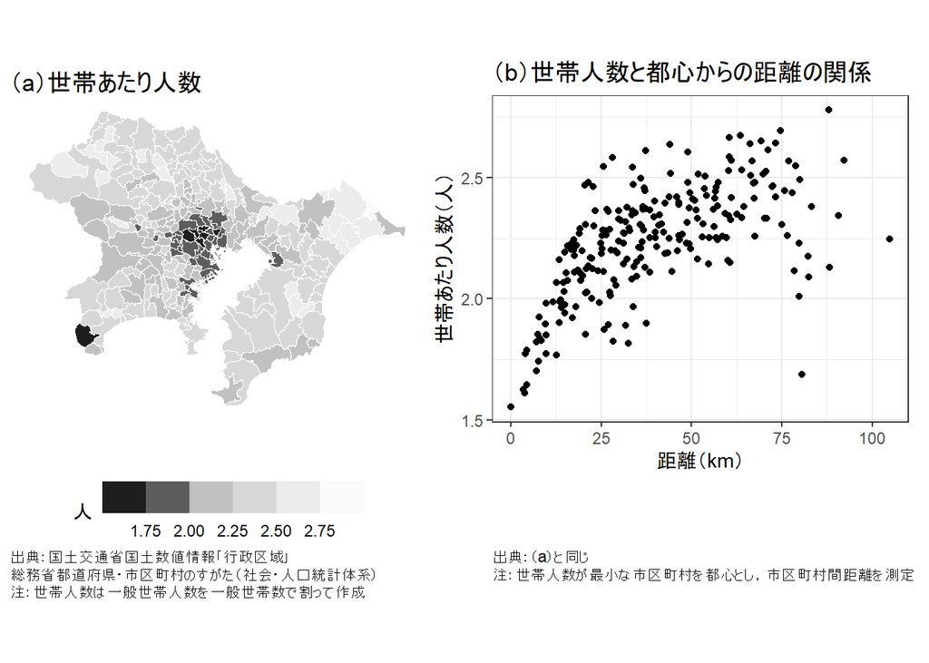

[都市内の住宅立地](https://shinichiro-iwata.github.io/lecture-notes-urban-econ/residential-location-choice.html)では，消費者を同質と仮定して空間構造を考えてきたため，上の問いには十分に答えられません．しかし，消費者の**異質性**を導入すると，異なる特徴をもつ消費者が都市内のどこに住むのかを考えられるようになります．そこで，ここでは消費者を異質な存在として捉え，上の問いを検討します．なお，以下では（人口が一定で，都市間移動のない）**閉鎖都市**を前提とします．

# 1 世帯人数の異質性

最初に，世帯人数の異質性を考えましょう．[住宅価格と子ども数](https://shinichiro-iwata.github.io/lecture-notes-urban-econ/housing-children.html)でも触れたように，子ども数と住宅消費（広さ）は補完関係になる場合があります．このとき，子どもを育てる世帯は広い住宅を求めるようになります．そして，住宅敷地面積が大きくなると住宅建物面積も大きくなると考えると，子どもを育てる世帯は広い敷地を求めると言い換えられます．この結果，子どもがいる世帯，すなわち世帯人数が多い世帯は，広い敷地を好むようになります．

そこで，消費者aは世帯人数の少ない世帯の消費者（世帯主）であり，消費者bは世帯人数の多い世帯の消費者（世帯主）だとしましょう．異なるのは世帯人数のみで，所得yと単位距離当たり交通費tは等しいとします．上の議論から，消費者bは消費者aに比べて広い住宅敷地を求める傾向があり，この異質性を**限界代替率**の違いで表すことにします．限界代替率とは，消費者が敷地面積の消費量を追加的に1単位増やしたときに，同一の効用に留まるためにあきらめてもよいその他の財の消費額の絶対値です．住宅敷地消費に対する選好が強い消費者bは，住宅敷地を拡大するために，その他の財を多くあきらめても効用を一定に保てるので，消費者aよりも限界代替率が大きくなると考えられます．

このことを示すのがと図3です．図3では，消費者aの無差別曲線と消費者bの無差別曲線がE点で交わっており，この点において両者の住宅敷地の消費量とその他の財の消費額の組み合わせは等しくなっています．E点における接点の傾きの絶対値が消費者の限界代替率を示しており，消費者bの限界代替率（β）が消費者aの限界代替率（α）よりも大きく描かれています．この違いを反映して，消費者aの無差別曲線と消費者bの無差別曲線は異なる形状になります．

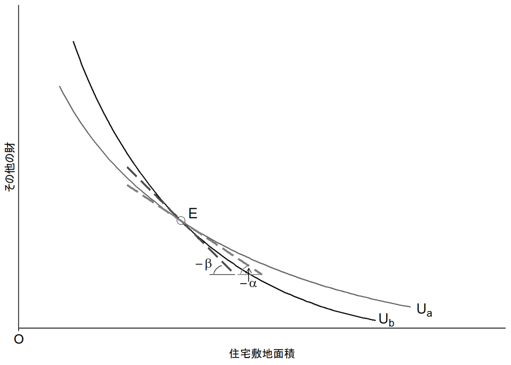

図3：消費者aとbの無差別曲線

それでは，消費者aとbが都心（中心地）に近いx<sub>0</sub>地点に立地したときの付け値地代を考えてみましょう（図4）．これを考える上で，立地均衡で達成される効用水準や可処分所得（純所得）を知る必要があります．立地均衡では，都市のどの地点に立地しても消費者の効用は等しくなりました．効用が等しいということは，都市内を移転する誘因が生じなくなるからです．しかし，消費者aと消費者bは無差別曲線の形状が異なるため，立地均衡において両者の効用が等しくなる必要はありません．効用が等しくなるのは，それぞれの消費者と同質的な消費者同士に限ります．例えば，消費者aと同質的な消費者がN<sub>a</sub>（人），消費者bと同質的な消費者がN<sub>b</sub>（人）存在するとすれば，立地均衡ではそれぞれの集団内で効用が等しくなります．図4では，立地均衡における消費者aの効用水準はU<sub>a</sub>に，消費者bの効用水準はU<sub>b</sub>になるとします．可処分所得については，両者の所得と交通費が等しかったため，いずれもy – tx<sub>0</sub>で，縦軸の切片の値は等しくなります．

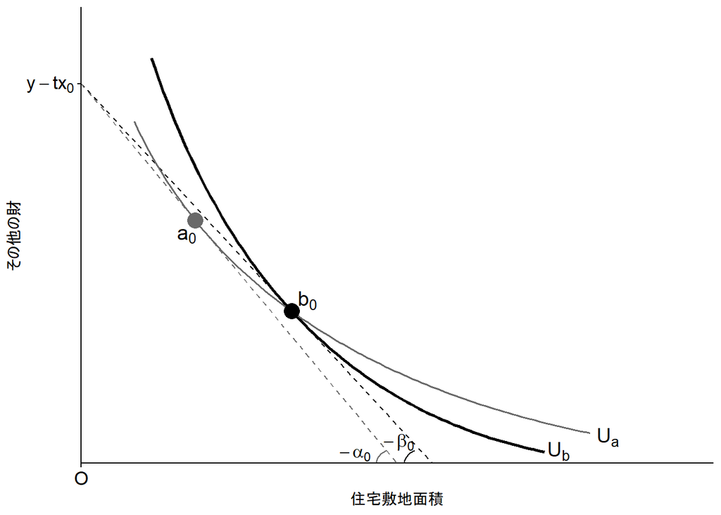

図4：中心地寄りのx<sub>0</sub>地点の最適点と付け値地代

消費者aの付け値地代は，この縦軸の切片を出発し，無差別曲線U<sub>a</sub>に接するように描かれる予算制約線の傾きの絶対値α<sub>0</sub>になります．それに対して，消費者bの付け値地代は，同じ切片を出発し，無差別曲線U<sub>b</sub>に接するように描かれる予算制約線の傾きの絶対値β<sub>0</sub>になります．それぞれの最適点（a<sub>0</sub>，b<sub>0</sub>）を比較すると，同じ地点でも，無差別曲線の違いを反映して，消費者bのほうが，消費者aに比べてその他の財の消費額を減らし，大きな住宅敷地面積を消費しようとしています．しかし，付け値地代を比較すると，α<sub>0</sub>がβ<sub>0</sub>を上回っています．したがって，x<sub>0</sub>地点において，地主は消費者bではなく消費者aに土地を貸すことになります．このことは，住宅敷地面積に対する選好が強い消費者bは，中心地周辺では付け値地代の競争に勝てないことを意味します．

次に，x<sub>0</sub>地点よりも中心地から遠い距離x<sub>1</sub>地点に立地したときの付け値地代を考えてみましょう（図5）．両者の可処分所得は等しく低下するため，縦軸の切片はy – tx<sub>1</sub>のように下方に移動します．それに対して，立地均衡の下では，効用水準に変化はありません．したがって，先と同じ手順で付け値地代を求めると，消費者aの付け値地代はα<sub>1</sub>に，消費者bの付け値地代はβ<sub>1</sub>になります．ここでも，最適点（a<sub>1</sub>，b<sub>1</sub>）を比較すると，消費者bのほうが，消費者aに比べてその他の財の消費額を減らし，大きな住宅敷地面積を消費しようとしています．ただし，先の場合とは異なり，付け値地代はβ<sub>1</sub>がα<sub>1</sub>を上回ります．したがって，x<sub>1</sub>地点においては，消費者aではなく消費者bに土地が貸し出されます．このことは，住宅敷地面積に対する選好が強い消費者bは，地代が相対的に低い郊外に向かわなければ土地を借りられないことを意味します．

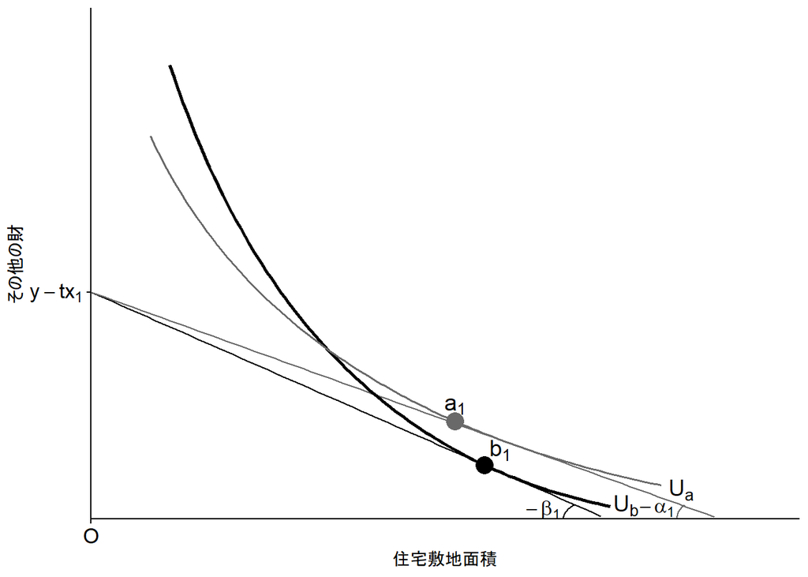

図5：郊外寄りのx<sub>1</sub>地点の最適点と付け値地代

図6は，世帯人数の異質性を考慮したときの都市の土地利用を示しています．破線r<sub>a</sub>は消費者aを含む少人数世帯の付け値地代曲線を示しています．図4から消費者bは中心地周辺では消費者aよりも付け値地代が低くなり，図5から郊外周辺では高くなります．このため，消費者bを含む多人数世帯の付け値地代曲線は図6の実線r<sub>b</sub>のように，r<sub>a</sub>よりも傾きが緩やに描かれることになります．なお，縦軸r<sub>f</sub>から出発する直線は農業地代を表しています．

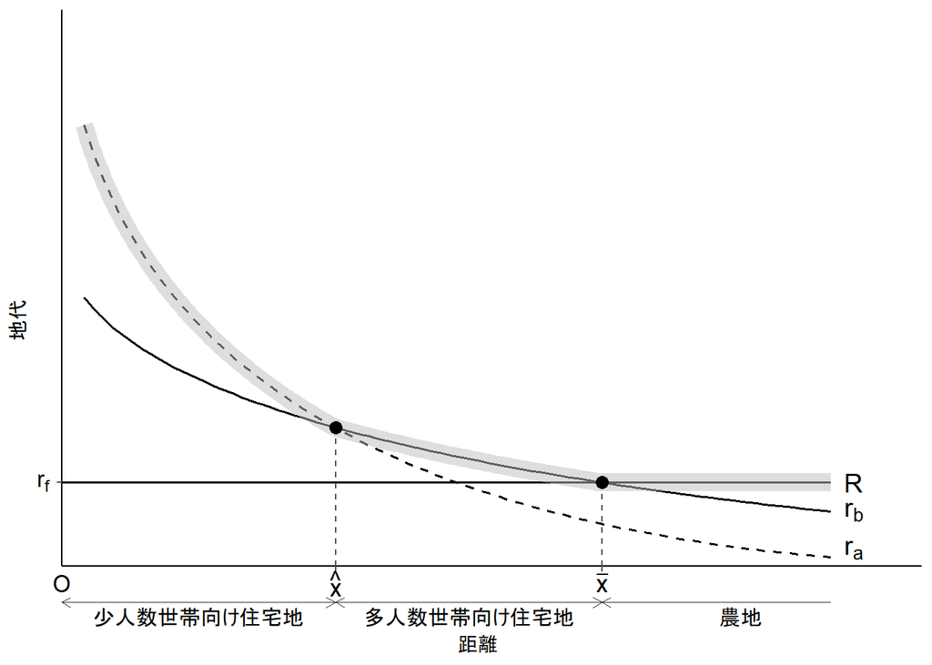

図6：世帯人数別の付け値地代曲線と市場地代曲線

[都市内の住宅立地](https://shinichiro-iwata.github.io/lecture-notes-urban-econ/residential-location-choice.html)第5節で述べたように，地主はできるだけ高い地代を支払う用意のある主体に土地を提供します．したがって，中心地（O地点）からx̂地点までがN<sub>a</sub>人の少人数世帯向けの住宅地として，x̂地点からx̄地点までがN<sub>b</sub>人の多人数世帯向けの住宅地として，そしてx̄から先が農地として割り当てられます．これを反映するように，市場地代曲線Rは，各地点の最高地代をなぞるように描かれます．

以上から，単一中心都市モデルを用いて，子育て世帯など世帯人数の多い消費者ほど郊外に立地する傾向を説明できます．

# 2 所得の異質性

単一中心都市モデルで消費者の異質性を考える典型例は，所得の異質性です．ここでは，消費者に高所得者と低所得者が存在する場合を想定し，それぞれの所得者層が都市内のどの場所に立地するのかを検討します．

このとき参考になるのが，[都市内の住宅立地](https://shinichiro-iwata.github.io/lecture-notes-urban-econ/residential-location-choice.html)第6節（2）の内容です．そこでは，所得が上昇すると，消費者はより広い敷地を求めて郊外を選好するため，中心地付近では付け値地代が低下し，郊外では上昇することを説明しました．同じ考え方は，所得の違いにも当てはまります．すなわち，図7のように，低所得者層の付け値地代曲線r<sub>L</sub>に比べて，高所得者層の付け値地代曲線r<sub>H</sub>は緩やかになります．

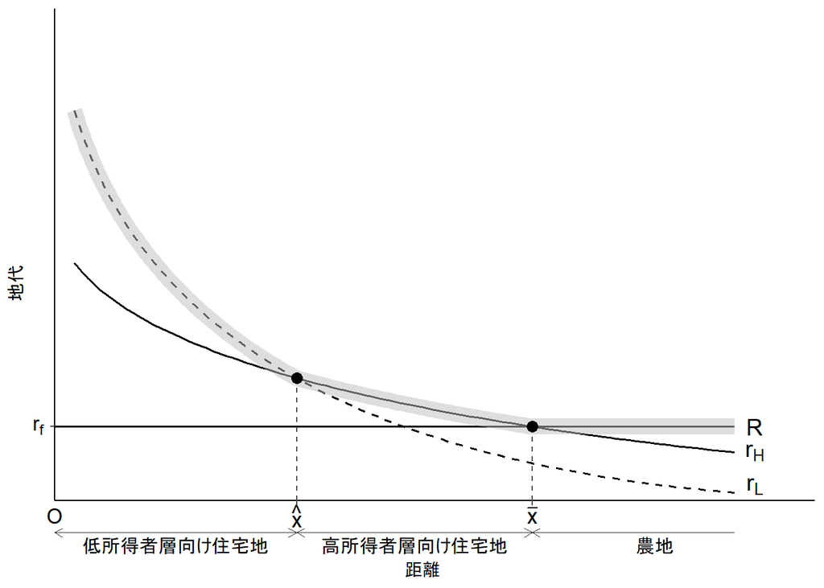

図7：所得別の付け値地代曲線と市場地代曲線

地主はできるだけ高い地代を支払う用意のある主体に土地を提供します．したがって，土地は中心地（O地点）からx̂地点までは低所得者層の消費者向け住宅地として提供され，x̂地点からx̄地点までは高所得者層の消費者向け住宅地として提供されます．そして，x̄地点から先は農地として提供されることになります．

ここで，高所得者層の付け値地代曲線が，都市全体で低所得者層の付け値地代曲線を上回り，低所得者層が都市から追い出される危惧はないのでしょうか．実は，都市間移動のない閉鎖都市を捉えた単一中心都市モデルではこのようなことは起こりません．低所得者層も都市内のどこかに立地する必要があるからです．

しかし，図7で得られた土地利用の配分は，図1と整合的ではないことに気づきます．この非整合性を考える上で手かがりになるのは，所得ではなく賃金の異質性です．そこで，消費者間に賃金の高低が存在すると想定し，この異質性を**単位距離当たり交通費**の違いに含めて表すことにします．この考え方は労働経済学に基づいています．労働経済学では，賃金が高い主体ほど，労働時間以外の時間利用に伴う機会費用が高いと考えます．なぜなら，労働以外に時間を配分するほど，失われる賃金が高くなるからです．単一中心都市モデルに話を置き換えると，賃金の高い消費者は交通に時間をかけることを避けるようになります．このことは，賃金の高い消費者は賃金の低い消費者に比べて，単位距離当たり交通費が高くなることを意味します．

それでは，高賃金を稼ぐ高所得者層の付け値地代曲線はどのように変化するでしょうか．参考になるのが，[都市内の住宅立地](https://shinichiro-iwata.github.io/lecture-notes-urban-econ/residential-location-choice.html)第6節（1）の内容です．そこでは，単位距離当たり交通費が低下したときの影響を考えました．ここでは，逆に上昇したときを考えましょう．単位距離当たりの交通費が上昇すると，消費者は郊外を選好する理由は弱くなり，中心地周辺に土地を求めるようになります．この結果，中心地付近では付け値地代が上昇し，郊外では低下するようになります．これは，所得が上昇した場合と逆の動きをしています．

以上をまとめると，賃金の上昇には2つの効果があることがわかります．1つは，交通時間の増加を避ける動きで，これは中心地付近を選好する動きにつながります．もう1つは，賃金の上昇が所得の上昇（所得効果）をもたらし，敷地面積の拡大を目指して郊外を選好する動きにつながります．このように，高賃金を稼ぐ高所得者層は，交通時間を犠牲にして敷地面積を拡大するか，あるいは敷地面積を犠牲にして交通時間を短くするかというトレードオフに直面します．図7は前者の場合を示しており，このとき，高賃金を稼ぐ高所得者層の付け値地代曲線の傾きの絶対値は，低所得者層のそれを下回ります．これに対して後者の場合には，図7とは異なり，高所得者層の付け値地代曲線の傾きの絶対値は，低所得者層のそれを上回ります（図8）．その結果，図8では，高所得者層の消費者向け住宅地が，都心寄りのO地点からx̂地点までの範囲に提供されることになります．

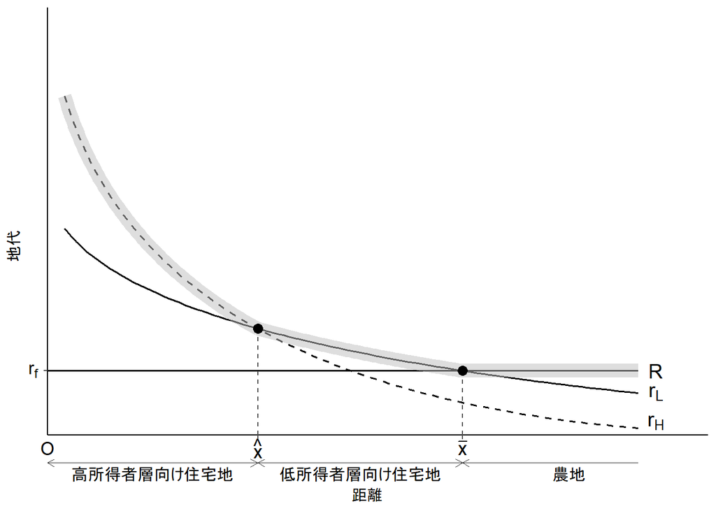

図8：賃金の相違を反映した所得別の付け値地代曲線と市場地代曲線

1都3県では，都心ほど課税所得で測った高所得者層が居住していました．このことは，，図8のような場合が現実にも生じている可能性を示唆します．[^4]

# 3 テキストガイド

消費者の異質性を考慮した単一中心都市モデルを紹介したテキストとして以下があります．

- 黒田達朗・田渕隆俊・中村良平（2008）[『都市と地域の経済学』](https://www.yuhikaku.co.jp/books/detail/9784641183711)有斐閣ブックス
- 高橋孝明（2012）[『都市経済学』](http://www.yuhikaku.co.jp/books/detail/9784641184060)有斐閣ブックス
- 中島賢太郎・手島健介・山崎潤一（2025）[『歩いて学ぶ都市経済学』](https://www.nippyo.co.jp/shop/book/9601.html)日本評論社．

世帯人数や賃金，労働・余暇時間を単一中心都市モデルに明示的に組み込み，分析手法および結果を整理したテキストとして次があります．

- Fujita, Masahisa (1989) [*Urban Economic Theory: Land Use and City Size*](https://www.cambridge.org/core/books/urban-economic-theory/1787328AC538E75129273E8B54A161FC), Cambridge University Press

# 補論

世帯人数の異質性，所得の異質性を考慮すると，中心地から郊外に向けて住宅敷地面積は大きくなることが予想されます．賃金の異質性を考慮した場合でも，高賃金を稼ぐ高所得者層は敷地面積を犠牲にして中心地寄りに立地します．したがって，中心地の敷地面積は小さくなる傾向があります．

それでは，実際に敷地面積と都心からの距離にはどのような関係があるでしょうか．ここでは，敷地面積の代わりに入手しやすい1住宅あたりの延べ面積を利用します．敷地と住宅面積が補完関係にあるならば，敷地面積が大きければ，住宅面積も大きくなります．

図9がこの関係を示した図です．ただし，値が得られない市区町村は観測から除いています．図9（a）および（b）は1都3県において，都心ほど1住宅あたり延べ面積が小さく，郊外に向かうにつれてそれが大きくなる傾向を示しています．[^5]

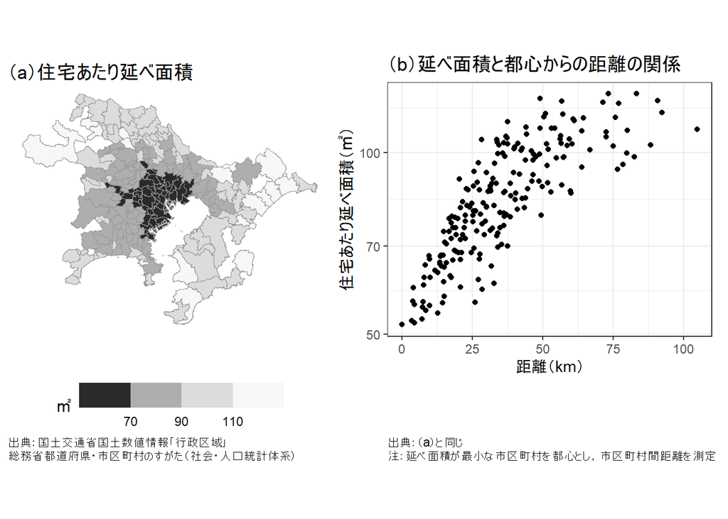

図9：1都3県市区町村別の1住宅あたり延べ面積（2023年度）

# R環境

**セッション情報**

- R version 4.5.2
  - RStudio 2026.01.0+392
  - rmarkdown 2.30

**使用したパッケージ**

- `tidyverse`，`sf`，`geosphere`

# リンク

[都市経済学講義ノート](https://shinichiro-iwata.github.io/lecture-notes-urban-econ/)

[Rによる地理空間データの可視化](https://shinichiro-iwata.github.io/geospatial-data-visualization/)

[Shinichiro Iwata](https://shinichiro-iwata.github.io/)

**アイコン**

Font Awesome 7.0.0

**生成AIの使用について**

ChatGPTのサービスを利用した後，内容を確認し，必要に応じて編集を行いました．

[^1]: 倉橋透（2021）[「大都市郊外の生活圏整備を コロナ後の都市・住宅政策」](https://www.nikkei.com/article/DGXZQOCD261ET0W1A820C2000000/)『日本経済新聞』2021年10月6日；堀大介（2023）[「「住宅難民」東京から隣県へ 30・40代，転出超過2万人」](https://www.nikkei.com/article/DGXZQOUD28BVF0Y3A220C2000000/)『日本経済新聞』2023年3月19日；日本経済新聞（2025）[「マンション高騰は「強欲インフレ」？ 首都圏の需要根強く土地足りず」](https://www.nikkei.com/article/DGXZQOUA256640V20C25A9000000/)『日本経済新聞』2025年10月26日
[^2]: 1人あたり課税所得が最も高いのは港区約1163万円です．
[^3]: 世帯あたり人数が最も少ないのは新宿区1.55人です．
[^4]: 家庭における女性の家事負担はあいかわらず重いままですが，女性の賃金も高いパワーカップルが近年増えています．かつての共働き世帯では，重い家事責任を負わされる女性の賃金は低いのが一般的でした． Iwata and Tamada（2014）（[The backward-bending commute times of married women with household responsibility](https://doi.org/10.1007/s11116-013-9458-5), *Transportation*, 41(2), 251-278.）は，単一中心都市モデルと同様に，賃金の高い職場は中心地のみにしかなく，賃金の低い職場は都市に一様に分布している場合に，こうした共働き世帯がどこに立地するかを分析しています．このモデルでは，家事時間に追われる女性は，低賃金の職場に通うために長距離通勤することは合理的ではありません．したがって，女性は男性の高賃金を利用して，敷地面積の大きい郊外に立地し，通勤時間を短くすることで余暇時間を確保します．ここで，女性にとって中心地でより高い賃金の就業機会が増えたとします．ただし，賃金が十分に高くない場合，中心地付近の住宅獲得競争に勝つのは難しく，そのまま郊外に立地続けて，中心地に通うことになります．この場合，女性は家事時間だけでなく通勤時間も長くなり，余暇時間を確保できません．さらに，女性の中心地での賃金が男性並みの高賃金になったとします．この場合，中心地付近に立地を変更することが可能となり，通勤時間を節約して余暇時間を確保できるようになります．これは，パワーカップルが都心周辺に住宅を構え得る事実を説明します．
[^5]: 1住宅あたり延べ面積が最も小さいのは新宿区の51.88㎡です．